# COVID

Alexander Bauer

7/27/2020

# Data

This file is an attempt to determine the pre-test and post-test probability of a positive covid test based on regional data and symptoms. As input it requires a time, a location, and a factor that applys to a percentage of the people living at that time and location. It’s output is the Pre-test Probability, Sensitivity, Specificity, Sensitivity + Specificity, the probability of getting a true positive result (based on Pre-test Probability, Sensitivity, and Specificity), and the probability of getting a false negative result (based on Pre-test Probability, Sensitivity, and Specificity), as well as a chart that illustrates where Pre-test Probability intercepts the probability of getting a true positive or negative result. Based on these outputs it is possible to determine if a factor could be used to accurately pretest for covid.

(Note: All percentages are written as a decimal in this program)

## Read Data

This section reads the input data file.

```r
covid.csv <- read.csv("owid-covid-data.csv")
```

## Summary

Overview of the raw data and basic general statistics about it.

### Coronavirus Summary Stats

Finds n, min, max, median

```r
kable(summary(covid.csv))
```

|  | iso_code | continent | location | date | total_cases | new_cases | new_cases_smoothed | total_deaths | new_deaths | new_deaths_smoothed | total_cases_per_million | new_cases_per_million | new_cases_smoothed_per_million | total_deaths_per_million | new_deaths_per_million | new_deaths_smoothed_per_million | new_tests | total_tests | total_tests_per_thousand | new_tests_per_thousand | new_tests_smoothed | new_tests_smoothed_per_thousand | tests_per_case | positive_rate | tests_units | stringency_index | population | population_density | median_age | … |
| --- | --- | --- | --- | --- | --- | --- | --- | --- | --- | --- | --- | --- | --- | --- | --- | --- | --- | --- | --- | --- | --- | --- | --- | --- | --- | --- | --- | --- | --- | --- |
|  | AFG : 233 | : 304 | Afghanistan: 233 | 2020-05-31: 211 | Min. : 0 | Min. : -2461 | Min. : -338.86 | Min. : 0 | Min. :-1918.00 | Min. :-232.143 | Min. : 0.00 | Min. :-265.189 | Min. :-19.206 | Min. : 0.000 | Min. :-41.0230 | Min. :-4.9650 | Min. : -3743.0 | Min. : 1 | Min. : 0.000 | Min. :-0.398 | Min. : 0 | Min. : 0.000 | Min. : 1.51 | Min. :0.000 | :23639 | Min. : 0.00 | Min. :8.090e+02 | Min. : 0.137 | Min. :15.1 | … |
|  | ARE : 233 | Africa : 8657 | Algeria : 233 | 2020-06-30: 211 | 1st Qu.: 27 | 1st Qu.: 0 | 1st Qu.: 0.43 | 1st Qu.: 0 | 1st Qu.: 0.00 | 1st Qu.: 0.000 | 1st Qu.: 14.13 | 1st Qu.: 0.000 | 1st Qu.: 0.070 | 1st Qu.: 0.000 | 1st Qu.: 0.0000 | 1st Qu.: 0.0000 | 1st Qu.: 924.5 | 1st Qu.: 36414 | 1st Qu.: 2.198 | 1st Qu.: 0.060 | 1st Qu.: 1028 | 1st Qu.: 0.062 | 1st Qu.: 12.03 | 1st Qu.:0.007 | people tested : 3809 | 1st Qu.: 38.89 | 1st Qu.:1.702e+06 | 1st Qu.: 39.497 | 1st Qu.:24.3 | … |
|  | ARM : 233 | Asia : 9329 | Armenia : 233 | 2020-07-31: 211 | Median : 655 | Median : 7 | Median : 11.00 | Median : 11 | Median : 0.00 | Median : 0.143 | Median : 206.28 | Median : 1.035 | Median : 2.235 | Median : 3.136 | Median : 0.0000 | Median : 0.0130 | Median : 3167.0 | Median : 151234 | Median : 11.874 | Median : 0.272 | Median : 3489 | Median : 0.286 | Median : 35.21 | Median :0.026 | people tested (incl. non-PCR): 160 | Median : 65.74 | Median :8.656e+06 | Median : 90.672 | Median :31.4 | … |
|  | AUS : 233 | Europe :10233 | Australia : 233 | 2020-08-01: 211 | Mean : 66864 | Mean : 1182 | Mean : 1168.04 | Mean : 3140 | Mean : 41.69 | Mean : 41.669 | Mean : 1350.30 | Mean : 20.118 | Mean : 19.815 | Mean : 46.578 | Mean : 0.5411 | Mean : 0.5418 | Mean : 19103.5 | Mean : 1032840 | Mean : 40.121 | Mean : 0.639 | Mean : 18059 | Mean : 0.610 | Mean : 202.10 | Mean :0.063 | samples tested : 2613 | Mean : 58.13 | Mean :9.178e+07 | Mean : 367.865 | Mean :31.5 | … |
|  | AUT : 233 | North America: 5849 | Austria : 233 | 2020-08-02: 211 | 3rd Qu.: 7162 | 3rd Qu.: 125 | 3rd Qu.: 129.86 | 3rd Qu.: 143 | 3rd Qu.: 2.00 | 3rd Qu.: 2.571 | 3rd Qu.: 1249.30 | 3rd Qu.: 12.809 | 3rd Qu.: 14.331 | 3rd Qu.: 27.931 | 3rd Qu.: 0.1700 | 3rd Qu.: 0.2430 | 3rd Qu.: 10967.0 | 3rd Qu.: 571909 | 3rd Qu.: 48.102 | 3rd Qu.: 0.763 | 3rd Qu.: 11378 | 3rd Qu.: 0.756 | 3rd Qu.: 122.38 | 3rd Qu.:0.081 | tests performed : 7432 | 3rd Qu.: 80.56 | 3rd Qu.:3.126e+07 | 3rd Qu.: 222.873 | 3rd Qu.:39.7 | … |
|  | AZE : 233 | Oceania : 1423 | Azerbaijan : 233 | 2020-08-03: 211 | Max. :22151281 | Max. :298098 | Max. :263435.71 | Max. :781123 | Max. :10542.00 | Max. :7464.000 | Max. :40145.29 | Max. :4944.376 | Max. :882.924 | Max. :1237.551 | Max. :200.0400 | Max. :63.1400 | Max. :926876.0 | Max. :68263933 | Max. :738.378 | Max. :22.359 | Max. :822470 | Max. :15.820 | Max. :47299.00 | Max. :0.662 | units unclear : 231 | Max. :100.00 | Max. :7.795e+09 | Max. :19347.500 | Max. :48.2 | … |
|  | (Other):36651 | South America: 2254 | (Other) :36651 | (Other) :36783 | NA’s :578 | NA’s :578 | NA’s :1359 | NA’s :578 | NA’s :578 | NA’s :1359 | NA’s :642 | NA’s :642 | NA’s :1424 | NA’s :642 | NA’s :642 | NA’s :1424 | NA’s :25911 | NA’s :25569 | NA’s :25569 | NA’s :25911 | NA’s :24394 | NA’s :24394 | NA’s :25422 | NA’s :25065 | units unclear (incl. non-PCR): 165 | NA’s :6569 | NA’s :71 | NA’s :1749 | NA’s :3896 | … |

### Coronavirus Raw Data

```r
#kable(covid.csv)
#Healthy_Population <- covid.csv$population - covid.csv$total_cases
```

# Setup

## Pretest Probability Calculator

The probability of the target disorder, usually abbreviated P(D+), can be calculated as the proportion of patients with the target disorder, out of all the patients with the symptoms(s), both those with and without the disorder:

P(D+) = D+ / (D+ + D-)

Probability of being sick = Sick / (Sick + Healthy)

Where D+ indicates the number of patients with target disorder, D- indicates the number of patients without target disorder, and P(D+) is the probability of the target disorder.

P(D+) = (True Positives + False Negatives) / ((True Positives + False Positives) + (True Negatives + False Negative))

P(D+) = Sensitivity / 1 - Specificity

P(D+) * (1 - Specificity) = Sensitivity

1 - Specificity = Sensitivity / P(D+)

1 = (Sensitivity / P(D+)) + Specificity

Specificity = 1 - (Sensitivity / p(D+))

P(D+) = Probability(T+)

Sensitivity measures the proportion of positives that are correctly identified (e.g., the percentage of sick people who are correctly identified as having some illness).

Specificity measures the proportion of negatives that are correctly identified (e.g., the percentage of healthy people who are correctly identified as not having some illness).

### Pretest Probability Calculator

```r
Pretest_Probability <- (covid.csv$total_cases) / (covid.csv$total_cases + covid.csv$population)

# Pretest Probability

#Specificity <- Pretest_Probability # Setup

#Sensitivity <- Pretest_Probability * (1 - Specificity) # Setup

#Specificity <- 1 - (Sensitivity / Pretest_Probability) # Specificity

#Sensitivity <- Pretest_Probability * (1 - Specificity) # Sensitivity

#kable(head(Pretest_Probability))
#kable(head(Specificity))
#kable(head(Sensitivity))
```

### Define P(Disease+|Test+) function (Red line)

### Define P(Disease+|Test-) function (Green line)

## How to Interpret Results

When the sensitivity is 0, the test will be positive in none of the diseased. At 0 sensitivity positive results are all false positive.

When the sensitivity is 1, the test will be positive in all of the diseased. Negative results will be all true negative.

When the specificity is 0, the test will be positive in all of the non-diseased. Negative results will be all false negative.

When the specificity is 1, the test will be positive in none of the non-diseased. Positive results will be all true positive.

If sensitivity + specificity = 1 and the post-test probability = pre-test probability, this test will function no better than randomized selection.

If sensitivity + specificity > 1, and the post-test probability > pre-test probability, and the test is positive; then this test has the potential to be informative.

If sensitivity + specificity < 1, and the post-test probability < pre-test probability, and the test is positive; then this test has the potential to be misleading. This type of result indicates that the disease is more likely if the test is negative. A test with this result can be informative if the test result is interpreted the other way around (opposite). (trying to figure out how to fix this)

The intercept of pretest probability with sensitivity is the predicted rate of getting true positive results.

The intercept of pretest probability with specificity is the rate of getting false negative results.

The black line represents the pretest probability for that specific factor.

## Chart Setup

Create combinations of pre-test probablities, sensitivities, and specificites

Add post-test probabilities, convert sensitivities and specificites to categories

Reshape data for ggplot2

## Chart of Potential Results

Red line P(Disease+|Test+) and Green line P(Disease+|Test-)

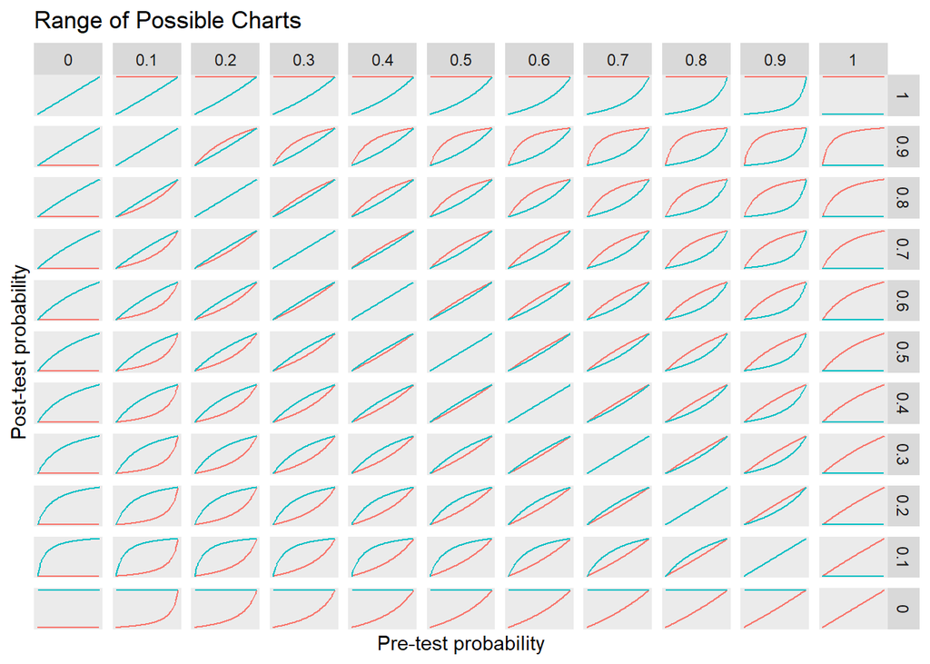

```r
p <-
    ggplot(covid_pretest_function2, aes(x = Pretest_Probability.test, y = Posttest_Probability.test, color = test.result)) +
    geom_line() +
    scale_x_continuous(breaks = NULL, name = "Pre-test probability") +          # X-axis
    scale_y_continuous(breaks = NULL, name = "Post-test probability") +         # Y-axis
    facet_grid(spec ~ sens) +                                                   # row ~ column
    guides(color = FALSE)                                                       # No legend

VP <- viewport(width = 0.975, height = 0.975, x = 0.0, y = 0.0, just = c(0,0))
InPlot <- p + labs(title = "Range of Possible Charts")            # top label

#grid.text("Specificity", x = 0.975, y = 0.5, rot = 270)          # right label

InPlot
```

This chart illustrates all the possible charts that could result from this program. A Straight diagonal line is equivalent to a coin toss i.e. not very useful. An accurate pretest will have a red line that’s in the upper left corner, that’s far away from the blue line. When the red line is horizontal at the top of the chart, the event is certain to happen. The distance between the red line and the the top of the chart represents how close the result is to being neccicarily true. The distance between the red line and the bottom of the chart represents how close the result is to being impossible. Similarly, the distance between the blue line and the top of the chart represents how close the result is to being impossible (but with only positive test results). While the distance between the blue line and the bottom of the chart represents how close the test is to always correctly identifying covid.

## Test Scenarios

### High Sensitivity and Specificity

When the sensitivity is 0, the test will be positive in none of the diseased. At 0 sensitivity positive results are all false positive. This test’s sensitivity value is 0.95, which is close to 1. This result indicates that there is a low likelyhood for getting false positive results when determining the probability that someone is sick .

When the specificity is 0, the test will be positive in all of the non-infected subects Negative results will be all false negative. This test ’s specificity value is 0.95, which is also very close to 1. This result indicates that there is a high probability of getting true negative results

For this test, sensitivity + specificity is 1.9 which is > 1.

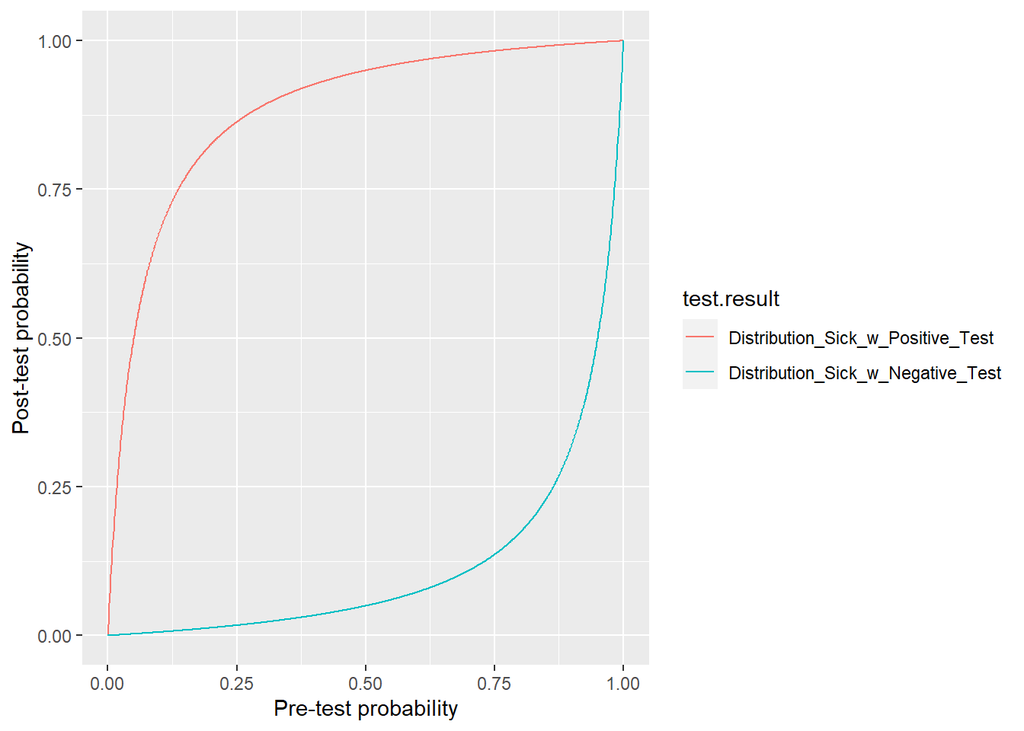

```r
covid_pretest_function3 <- expand.grid(Pretest_Probability.test = seq(0, 1, 0.001),
                   sens     = 0.95,
                   spec     = 0.95
                   )

covid_pretest_function3 <- within(covid_pretest_function3, {
    Distribution_Sick_w_Positive_Test <- Distribution_Sick_w_Positive_Test(Pretest_Probability.test, sens, spec)
    Distribution_Sick_w_Negative_Test <- Distribution_Sick_w_Negative_Test(Pretest_Probability.test, sens, spec)
})

covid_pretest_function3 <- melt(covid_pretest_function3, id.vars = c("Pretest_Probability.test", "sens", "spec"),
             measure.vars  = c("Distribution_Sick_w_Positive_Test","Distribution_Sick_w_Negative_Test"),
             variable.name = "test.result", value.name = "Posttest_Probability.test")

ggplot(covid_pretest_function3, aes(x = Pretest_Probability.test, y = Posttest_Probability.test, color = test.result)) +
    geom_line() +
    scale_x_continuous(name = "Pre-test probability") +
    scale_y_continuous(name = "Post-test probability")
```

If the test is positive, sensitivity + specificity < 1, and the post-test probability < pre-test probability, then this test has a high possibility of being misleading unless the results are interpreted differently.

Sensitivity + specificity is 1.9 and is > 1, which indicates that this test does not meet the requirements for a different interpretation.

High sensitivity and specificity shows that this result has a high likelyhood of being signifigant since there is a good chance of getting a true negative or true positive when using this test.

### High Sensitivity and Low Specificity

When the sensitivity is 0, the test will be positive in none of the diseased. At 0 sensitivity positive results are all false positive. This test’s sensitivity value is 0.95, which is close to 1. This result indicates that there is a low likelyhood for getting false positive results when determining the probability that someone is sick .

For this test, sensitivity + specificity is 1.2 which is > 1.

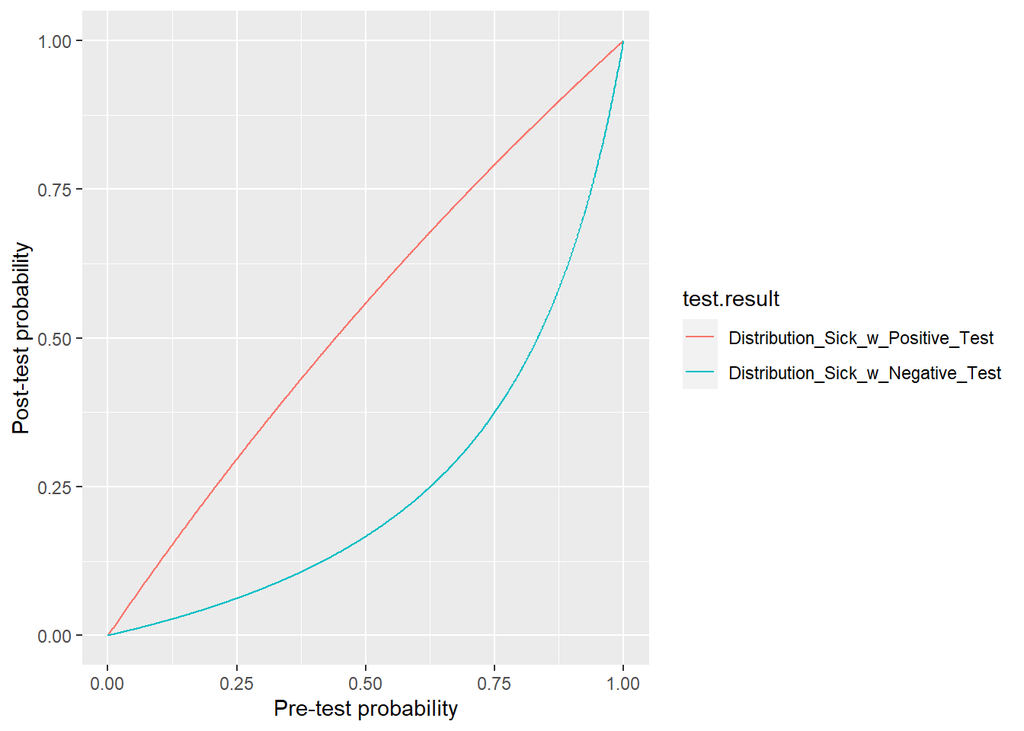

```r
covid_pretest_function3 <- expand.grid(Pretest_Probability.test = seq(0, 1, 0.001),
                   sens     = 0.95,
                   spec     = 0.25
                   )

covid_pretest_function3 <- within(covid_pretest_function3, {
    Distribution_Sick_w_Positive_Test <- Distribution_Sick_w_Positive_Test(Pretest_Probability.test, sens, spec)
    Distribution_Sick_w_Negative_Test <- Distribution_Sick_w_Negative_Test(Pretest_Probability.test, sens, spec)
})

covid_pretest_function3 <- melt(covid_pretest_function3, id.vars = c("Pretest_Probability.test", "sens", "spec"),
             measure.vars  = c("Distribution_Sick_w_Positive_Test","Distribution_Sick_w_Negative_Test"),
             variable.name = "test.result", value.name = "Posttest_Probability.test")

ggplot(covid_pretest_function3, aes(x = Pretest_Probability.test, y = Posttest_Probability.test, color = test.result)) +
    geom_line() +
    scale_x_continuous( name = "Pre-test probability") +
    scale_y_continuous(    name = "Post-test probability")
```

If the test is positive, sensitivity + specificity < 1, and the post-test probability < pre-test probability, then this test has a high possibility of being misleading unless the results are interpreted differently.

Sensitivity + specificity is 1.2 and is > 1, which indicates that this test does not meet the requirements for a different interpretation.

### Low Sensitivity and High Specificity

When the sensitivity is 0, the test will be positive in none of the diseased. At 0 sensitivity positive results are all false positive. This test’s sensitivity value is 0.25, which is fairly close to 0. This result indicates that there is a high likelyhood for getting false positive results when determining the probability that someone is sick.

When the specificity is 0, the test will be positive in all of the non-infected subects Negative results will be all false negative. This test’s specificity value is 0.95, which is close to 1. This result indicates that there is a high probability of getting true negative results.

For this test, sensitivity + specificity is 1.2 which is > 1.

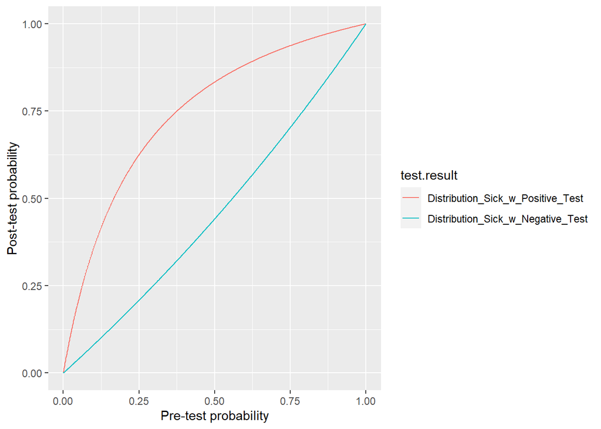

```r
covid_pretest_function3 <- expand.grid(Pretest_Probability.test = seq(0, 1, 0.001),
                   sens     = 0.25,
                   spec     = 0.95
                   )

covid_pretest_function3 <- within(covid_pretest_function3, {
    Distribution_Sick_w_Positive_Test <- Distribution_Sick_w_Positive_Test(Pretest_Probability.test, sens, spec)
    Distribution_Sick_w_Negative_Test <- Distribution_Sick_w_Negative_Test(Pretest_Probability.test, sens, spec)
})

covid_pretest_function3 <- melt(covid_pretest_function3, id.vars = c("Pretest_Probability.test", "sens", "spec"),
             measure.vars  = c("Distribution_Sick_w_Positive_Test","Distribution_Sick_w_Negative_Test"),
             variable.name = "test.result", value.name = "Posttest_Probability.test")

ggplot(covid_pretest_function3, aes(x = Pretest_Probability.test, y = Posttest_Probability.test, color = test.result)) +
    geom_line() +
    scale_x_continuous( name = "Pre-test probability") +
    scale_y_continuous(    name = "Post-test probability")
```

If the test is positive, sensitivity + specificity < 1, and the post-test probability < pre-test probability, then this test has a high possibility of being misleading unless the results are interpreted differently.

Sensitivity + specificity is 1.2 and is > 1, which indicates that this test does not meet the requirements for a different interpretation.

Low sensitivity and high specificity shows that this result has a decent likelyhood of being signifigant since there is a good chance of getting a true negative but the likelyhood of getting a true positive is slightly higher. This test may be signifigant but also likely has a high margin of error

### Low Sensitivity and Specificity

When the sensitivity is 0, the test will be positive in none of the diseased. At 0 sensitivity positive results are all false positive. This test’s sensitivity value is 0.25, which is fairly close to 0. This result indicates that there is a high likelyhood for getting false positive results when determining the probability that someone is sick.

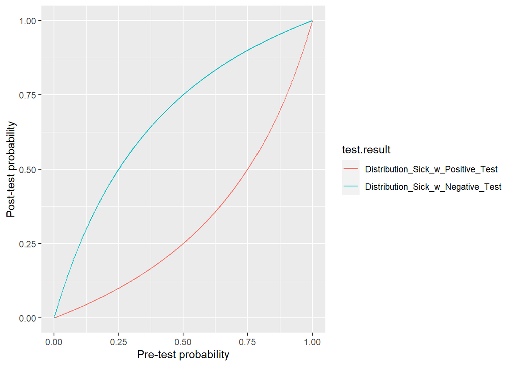

```r
covid_pretest_function3 <- expand.grid(Pretest_Probability.test = seq(0, 1, 0.001),
                   sens     = 0.25,
                   spec     = 0.25
                   )

covid_pretest_function3 <- within(covid_pretest_function3, {
    Distribution_Sick_w_Positive_Test <- Distribution_Sick_w_Positive_Test(Pretest_Probability.test, sens, spec)
    Distribution_Sick_w_Negative_Test <- Distribution_Sick_w_Negative_Test(Pretest_Probability.test, sens, spec)
})

covid_pretest_function3 <- melt(covid_pretest_function3, id.vars = c("Pretest_Probability.test", "sens", "spec"),
             measure.vars  = c("Distribution_Sick_w_Positive_Test","Distribution_Sick_w_Negative_Test"),
             variable.name = "test.result", value.name = "Posttest_Probability.test")

ggplot(covid_pretest_function3, aes(x = Pretest_Probability.test, y = Posttest_Probability.test, color = test.result)) +
    geom_line() +
    scale_x_continuous( name = "Pre-test probability") +
    scale_y_continuous(    name = "Post-test probability")
```

If the test is positive, sensitivity + specificity < 1, and the post-test probability < pre-test probability, then this test has a high possibility of being misleading unless the results are interpreted differently.

# Coronavirus Scenarios

## USA

```r
covid.usa <- subset(covid.csv, iso_code=="USA" & date == "2020-08-19")
covid.usa[,18] <- 74830464
covid.usa[,24] <- 6.1
Healthy_Population.usa <- covid.usa$population - covid.usa$total_cases

Covid.tf <- vector(mode = "logical", length = covid.usa$population/100) ## Creates truth table
Covid.tf[0:(covid.usa$total_cases)/100] <- TRUE

## Selects time and location for test
```

### P(t+) for diabetes

```r
## Calculates the percentage of the area's population under the proper category

Percent_Targeted.diabetes <- covid.usa$diabetes_prevalence / 100 # Percent of US Population w diabetes as decimal

Healthy_Population.diabetes <- covid.usa$population - covid.usa$total_cases

Target_Population.diabetes <-  Healthy_Population.diabetes * Percent_Targeted.diabetes

Diabetic_Population <- (covid.usa$population*(Percent_Targeted.diabetes)) # Number of Americans w Diabetes

Pretest_Probability.diabetes <- (covid.usa$total_cases) / (covid.usa$total_cases + Target_Population.diabetes) # Pretest probability

ref.diabetes <- vector(mode = "logical", length = covid.usa$population/100)
ref.diabetes[0:Diabetic_Population/100] <- TRUE # creates truth table to represent which americans have diabetes (/100 to save processing power)

Sensitivity.diabetes <- sensitivity(as.factor(Covid.tf), as.factor(ref.diabetes), positive = levels(as.factor(Covid.tf))[2]) # Finds sensitivity by comparing truth tables

Specificity.diabetes <- abs(1 - (Sensitivity.diabetes / Pretest_Probability.diabetes)) # Finds specificity based on the pretest probability and the specificity

TP.diabetes <- Pretest_Probability.diabetes * Sensitivity.diabetes # True Positives
FN.diabetes <- Pretest_Probability.diabetes - TP.diabetes # False Negatives
TN.diabetes <- (1 - Pretest_Probability.diabetes) * Specificity.diabetes # True Negatives
FP.diabetes <- (1 - Pretest_Probability.diabetes) - TN.diabetes # False Positives

### Table

sens_spec.diabetes <- Sensitivity.diabetes + Specificity.diabetes # Adds the sensitivity and specificity together

SwP.diabetes <- Distribution_Sick_w_Positive_Test(Pretest_Probability.diabetes, Sensitivity.diabetes, Specificity.diabetes) # Probability of getting a true positive
SwN.diabetes <- Distribution_Sick_w_Negative_Test(Pretest_Probability.diabetes, Sensitivity.diabetes, Specificity.diabetes) # Probability of getting a false positive

Pretest_Values.diabetes <- as.array(c(Pretest_Probability.diabetes,Specificity.diabetes,Sensitivity.diabetes,sens_spec.diabetes, SwP.diabetes, SwN.diabetes)) # arranges table

rownames(Pretest_Values.diabetes) <- c("Pretest Probability", "Specificity", "Sensitivity", "Sensitivity + Specificity", "Sick With Positive", "Sick With Negative") # Adds row names

kable(Pretest_Values.diabetes)
```

|  | x |
| --- | --- |
| Pretest Probability | 0.1350148 |
| Specificity | 0.1369401 |
| Sensitivity | 0.1535037 |
| Sensitivity + Specificity | 0.2904438 |
| Sick With Positive | 0.0270121 |
| Sick With Negative | 0.4910594 |

When the sensitivity is 0, the test will be positive in none of the diseased. At 0 sensitivity positive results are all false positive. This test’s sensitivity value is 0.1535037, which is fairly close to 0. This result indicates that there is a high likelyhood for getting false positive results when determining the probability that someone is sick.

When the specificity is 0, the test will be positive in all of the non-infected subects Negative results will be all false negative. This test’s specificity value is 0.1369401, which is close to 0. This result indicates that there is a high probability of getting false negative result.

Plot:

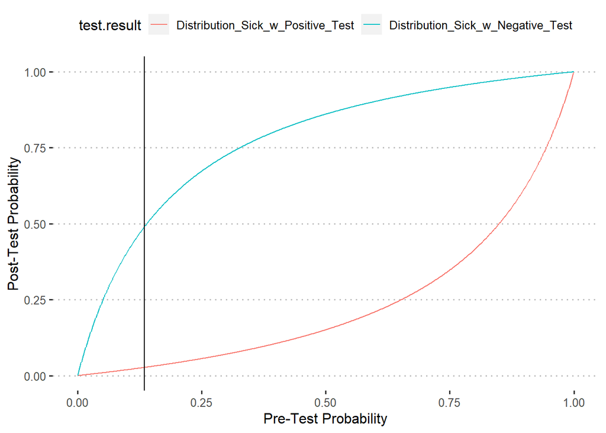

```r
covid_pretest_function4 <- expand.grid(Pretest_Probability.test = seq(0, 1, 0.001),
                   sens     = as.numeric(Sensitivity.diabetes),
                   spec     = as.numeric(Specificity.diabetes)
                   )

covid_pretest_function4 <- within(covid_pretest_function4, {
    Distribution_Sick_w_Positive_Test <- Distribution_Sick_w_Positive_Test(Pretest_Probability.test, sens, spec)
    Distribution_Sick_w_Negative_Test <- Distribution_Sick_w_Negative_Test(Pretest_Probability.test, sens, spec)
})

covid_pretest_function4 <- melt(covid_pretest_function4, id.vars = c("Pretest_Probability.test", "sens", "spec"),
             measure.vars  = c("Distribution_Sick_w_Positive_Test","Distribution_Sick_w_Negative_Test"),
             variable.name = "test.result", value.name = "Posttest_Probability.test")

ggplot(covid_pretest_function4, aes(x = Pretest_Probability.test, y = Posttest_Probability.test, color = test.result)) +
    geom_line() + geom_vline(xintercept = as.numeric(Pretest_Probability.diabetes)) +
    scale_x_continuous(name = "Pre-Test Probability") +
    scale_y_continuous(name = "Post-Test Probability") + theme_pubclean()
```

If the test is positive, sensitivity + specificity < 1, and the post-test probability < pre-test probability, then this test has a high possibility of being misleading unless the results are interpreted differently.

Low sensitivity and specificity shows that this result has a decent likelyhood of being insignifigant since there is a greater chance of getting a false positive than a true positive. This test may be not be very accurate.

At the pretest probability of 0.1350148, the sick will test positive at a rate of 0.0270121 and negative at a rate of 0.4910594 Pretesting based on diabetes has a high chance to result in false negatives.

### P(t+) for % Over 65

```r
## Calculates the percentage of the area's population under the proper category

Percent_Targeted.Over_65 <-  covid.usa$aged_65_older / 100 # Percent of US Population w diabetes as decimal

Healthy_Population.Over_65 <- covid.usa$population - covid.usa$total_cases

Target_Population.Over_65 <-  Healthy_Population.Over_65 * Percent_Targeted.Over_65

Over_65_Population <- (covid.usa$population*(Percent_Targeted.Over_65)) # Population over 65

Pretest_Probability.Over_65 <- (covid.usa$total_cases) / (covid.usa$total_cases + Target_Population.Over_65) # Pretest Probability


ref.Over_65 <- vector(mode = "logical", length = covid.usa$population/100)
ref.Over_65[0:Over_65_Population/100] <- TRUE # creates truth table to represent which americans have diabetes (/100 to save processing power)

Sensitivity.Over_65 <- sensitivity(as.factor(Covid.tf), as.factor(ref.Over_65), positive = levels(as.factor(Covid.tf))[2]) # Finds sensitivty by comparing truth tables

Specificity.Over_65 <- abs(1 - (Sensitivity.Over_65 / Pretest_Probability.Over_65)) # Finds specificity based on the pretest probability and the specificity

TP.Over_65 <- Pretest_Probability.Over_65 * Sensitivity.Over_65 # True Positives
FN.Over_65 <- Pretest_Probability.Over_65 - TP.Over_65 # False Negatives
TN.Over_65 <- (1 - Pretest_Probability.Over_65) * Specificity.Over_65 # True Negatives
FP.Over_65 <- (1 - Pretest_Probability.Over_65) - TN.Over_65 # False Positives

sens_spec.Over_65 <- Sensitivity.Over_65 + Specificity.Over_65 # Adds sensitivity and specificity

SwP.Over_65 <- Distribution_Sick_w_Positive_Test(Pretest_Probability.Over_65, Sensitivity.Over_65, Specificity.Over_65) # Probability of getting a true positive
SwN.Over_65 <- Distribution_Sick_w_Negative_Test(Pretest_Probability.Over_65, Sensitivity.Over_65, Specificity.Over_65) # Probability of getting a false positive

Pretest_Values.Over_65 <- as.array(c(Pretest_Probability.Over_65,Specificity.Over_65,Sensitivity.Over_65,sens_spec.Over_65, SwP.Over_65, SwN.Over_65)) # arranges table

rownames(Pretest_Values.Over_65) <- c("Pretest Probability", "Specificity", "Sensitivity", "Sensitivity + Specificity", "Sick With Positive", "Sick With Negative") # Adds row names

kable(Pretest_Values.Over_65)
```

|  | x |
| --- | --- |
| Pretest Probability | 0.0985074 |
| Specificity | 0.0908962 |
| Sensitivity | 0.1074614 |
| Sensitivity + Specificity | 0.1983576 |
| Sick With Positive | 0.0127518 |
| Sick With Negative | 0.5176007 |

When the sensitivity is 0, the test will be positive in none of the diseased. At 0 sensitivity positive results are all false positive. This test’s sensitivity value is 0.1074614, which is fairly close to 0. This result indicates that there is a high likelyhood for getting false positive results when determining the probability that someone is sick.

When the specificity is 0, the test will be positive in all of the non-infected subects Negative results will be all false negative. This test’s specificity value is 0.0908962, which is close to 0. This result indicates that there is a high probability of getting false negative result.

Plot:

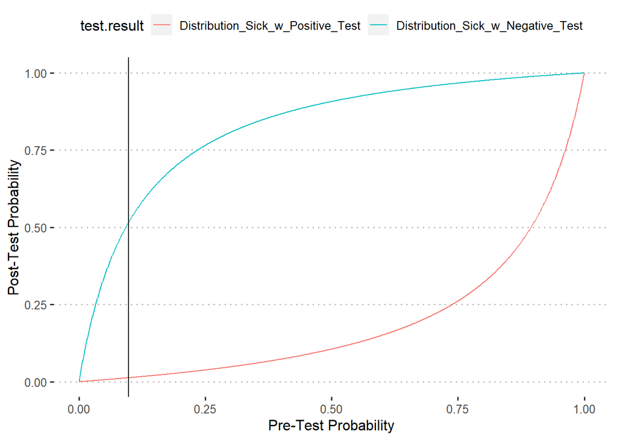

```r
covid_pretest_function5 <- expand.grid(Pretest_Probability.test = seq(0, 1, 0.001),
                   sens     = Sensitivity.Over_65,
                   spec     = Specificity.Over_65
                   )

covid_pretest_function5 <- within(covid_pretest_function5, {
    Distribution_Sick_w_Positive_Test <- Distribution_Sick_w_Positive_Test(Pretest_Probability.test, sens, spec)
    Distribution_Sick_w_Negative_Test <- Distribution_Sick_w_Negative_Test(Pretest_Probability.test, sens, spec)
})

covid_pretest_function5 <- melt(covid_pretest_function5, id.vars = c("Pretest_Probability.test", "sens", "spec"),
             measure.vars  = c("Distribution_Sick_w_Positive_Test","Distribution_Sick_w_Negative_Test"),
             variable.name = "test.result", value.name = "Posttest_Probability.test")

ggplot(covid_pretest_function5, aes(x = Pretest_Probability.test, y = Posttest_Probability.test, color = test.result)) +
    geom_line() + geom_vline(xintercept = as.numeric(Pretest_Probability.Over_65)) +
    scale_x_continuous(name = "Pre-Test Probability") +
    scale_y_continuous(name = "Post-Test Probability") + theme_pubclean()
```

If the test is positive, sensitivity + specificity < 1, and the post-test probability < pre-test probability, then this test has a high possibility of being misleading unless the results are interpreted differently.

Low sensitivity and specificity shows that this result has a decent likelyhood of being insignifigant since there is a greater chance of getting a false positive than a true positive. This test may be not be very accurate.

At the pretest probability of 0.0985074, the sick will test positive at a rate of 0.0127518 and negative at a rate of 0.5176007 Pretesting based on % over 65 has a high chance to result in false negatives.

### P(t+) for % Over 70

```r
## Calculates the percentage of the area's population under the proper category

Percent_Targeted.Over_70 <- covid.usa$aged_70_older / 100

Healthy_Population.Over_70 <- covid.usa$population - covid.usa$total_cases

Target_Population.Over_70 <-  Healthy_Population.Over_70 * Percent_Targeted.Over_70

Over_70_Population <- (covid.usa$population*(Percent_Targeted.Over_70)) # Population that's Over 70

ref.Over_70 <- vector(mode = "logical", length = covid.usa$population/100)
ref.Over_70[0:Over_70_Population/100] <- TRUE # Creates truth table for being over 70 or not (/100 to conserve processing power)

Pretest_Probability.Over_70 <- (covid.usa$total_cases) / (covid.usa$total_cases + Target_Population.Over_70) # Pretest Probability

Sensitivity.Over_70 <- sensitivity(as.factor(Covid.tf), as.factor(ref.Over_70), positive = levels(as.factor(Covid.tf))[2]) # Compares truth tables to get sensitivity

Specificity.Over_70 <- abs(1 - (Sensitivity.Over_70 / Pretest_Probability.Over_70)) # Specificity

TP.Over_70 <- Pretest_Probability.Over_70 * Sensitivity.Over_70 # True Positives
FN.Over_70 <- Pretest_Probability.Over_70 - TP.Over_70 # False Negatives
TN.Over_70 <- (1 - Pretest_Probability.Over_70) * Specificity.Over_70 # True Negatives
FP.Over_70 <- (1 - Pretest_Probability.Over_70) - TN.Over_70 # False Positives

sens_spec.Over_70 <- Sensitivity.Over_70 + Specificity.Over_70 # Adds sensitivity and specificity

SwP.Over_70 <- Distribution_Sick_w_Positive_Test(Pretest_Probability.Over_70, Sensitivity.Over_70, Specificity.Over_70) # Probability of getting a true positive
SwN.Over_70 <- Distribution_Sick_w_Negative_Test(Pretest_Probability.Over_70, Sensitivity.Over_70, Specificity.Over_70) # Probability of getting a false positive

Pretest_Values.Over_70 <- as.array(c(Pretest_Probability.Over_70,Specificity.Over_70,Sensitivity.Over_70,sens_spec.Over_70, SwP.Over_70, SwN.Over_70)) # arranges table

rownames(Pretest_Values.Over_70) <- c("Pretest Probability", "Specificity", "Sensitivity", "Sensitivity + Specificity", "Sick With Positive", "Sick With Negative") # Adds row names

kable(Pretest_Values.Over_70)
```

|  | x |
| --- | --- |
| Pretest Probability | 0.1475273 |
| Specificity | 0.1536281 |
| Sensitivity | 0.1701916 |
| Sensitivity + Specificity | 0.3238197 |
| Sick With Positive | 0.0336289 |
| Sick With Negative | 0.4831395 |

Interpreting results:

When the sensitivity is 0, the test will be positive in none of the diseased. At 0 sensitivity positive results are all false positive. This test’s sensitivity value is 0.1701916, which is somewhat close to 0. This result indicates that there is a high likelyhood for getting false positive results when determining the probability that someone is sick when considering the percentage of the population over 70 as a risk factor.

When the specificity is 0, the test will be positive in all of the non-infected subects Negative results will be all false negative. This test ’s specificity value is 0.1536281, which is also very close to 0. This result indicates that there is a high probability of getting false positive results when determining the probability that someone is sick when considering the percentage of the population over 70 as a risk factor

For this test, sensitivity + specificity is 0.3238197 which is < 1.

Plot:

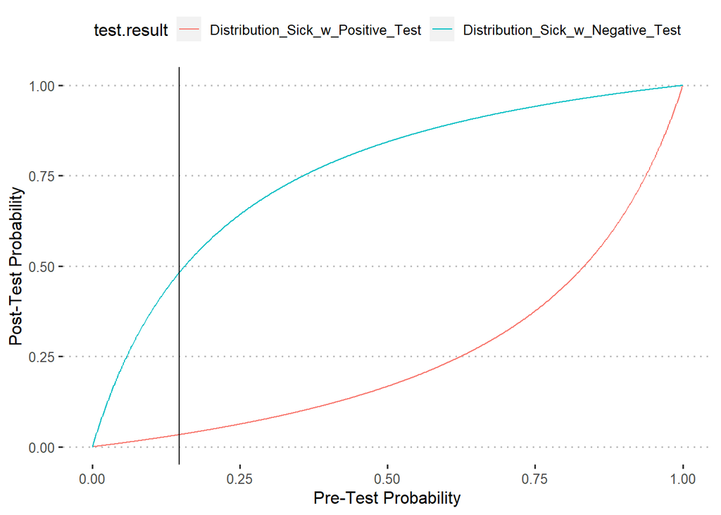

```r
covid_pretest_function6 <- expand.grid(Pretest_Probability.test = seq(0, 1, 0.001),
                   sens     = as.numeric(Sensitivity.Over_70),
                   spec     = as.numeric(Specificity.Over_70)
                   )

covid_pretest_function6 <- within(covid_pretest_function6, {
    Distribution_Sick_w_Positive_Test <-    abs(Distribution_Sick_w_Positive_Test(Pretest_Probability.test, sens, spec))
    Distribution_Sick_w_Negative_Test <- Distribution_Sick_w_Negative_Test(Pretest_Probability.test, sens, spec)
})

covid_pretest_function6 <- melt(covid_pretest_function6, id.vars = c("Pretest_Probability.test", "sens", "spec"),
             measure.vars  = c("Distribution_Sick_w_Positive_Test","Distribution_Sick_w_Negative_Test"),
             variable.name = "test.result", value.name = "Posttest_Probability.test")

ggplot(covid_pretest_function6, aes(x = Pretest_Probability.test, y = Posttest_Probability.test, color = test.result)) +
    geom_line() + geom_vline(xintercept = as.numeric(Pretest_Probability.Over_70)) +
    scale_x_continuous(name = "Pre-Test Probability") +
    scale_y_continuous(name = "Post-Test Probability") + theme_pubclean()
```

If the test is positive, sensitivity + specificity < 1, and the post-test probability < pre-test probability, then this test has a high possibility of being misleading unless the results are interpreted differently.

This plot indicates that the post-test probability of getting a negative test result is ~ 50% when considering the percentage of the population over 70 as a risk factor for being infected. However, the very low sensitivity and specificity shows that this result may not be very signifigant since there is a high chance of getting a false negative or false positive when using this test.

If the test is positive, sensitivity + specificity < 1, and the post-test probability < pre-test probability, then this test has a high possibility of being misleading unless the results are interpreted differently.

Low sensitivity and specificity shows that this result has a decent likelyhood of being insignifigant since there is a greater chance of getting a false positive than a true positive. This test may be not be very accurate.